# QP: Data Analysis

# Dataset

Below are the first six rows of the dataset. Rows show Dispositional root + Speaker combination, and columns show themes/figures tested. Speakers were asked to provide a configuration for a given root+theme combination; if they provided it, the cells show a 1. If they said the combination was not possible, the cells show a 0. However, not all possible pairs of root+theme were tested, because of previous knowledge that that combination was not possible. Those cases are also coded with 0. Cases in which a participant was not asked an expected combination are coded NA. Marginal cases, that is, those in which participants were doubtful or showed that the root could be applied to only part of the figure tested, are coded 0.5.

```r
#Import dataset
dataset <- read_csv("../QP_Data/disp_dataset.csv", col_types = cols(Root = col_factor(),
                                                                    Participant = col_factor()))
head(dataset)
```

| Root | Participant | suum | tuunich | nook | che | wiinik | peek | kaan | taablaklaabos | nalhek | xim | kamyoon | ha | plastilina | luuch | poomo | maaskab | hun | arena |
| --- | --- | --- | --- | --- | --- | --- | --- | --- | --- | --- | --- | --- | --- | --- | --- | --- | --- | --- | --- |
| ak | EMB | 0 | 0 | 0 | 0 | 0 | 0 | 0 | 0 | 0 | 0 | 0 | 1 | 0 | 0 | 0 | 0 | 0 | 0 |
| ak | FEE | 0 | 0 | 0 | 0 | 0 | 0 | 0 | 0 | 0 | 0 | 0 | 1 | 0 | 0 | 0 | 0 | 0 | 0 |
| ak | NMP | 0 | 0 | 0 | 0 | 0 | 0 | 0 | 0 | 0 | 0 | 0 | NA | 0 | 0 | 0 | 0 | 0 | 0 |
| ak | RMC | 0 | 0 | 0 | 0 | 0 | 0 | 0 | 0 | 0 | 0 | 0 | 1 | 0 | 0 | 0 | 0 | 0 | 0 |
| ak | SBM | 0 | 0 | 0 | 0 | 0 | 0 | 0 | 0 | 0 | 0 | 0 | 1 | 0 | 0 | 0 | 0 | 0 | 0 |
| ak | SME | 0 | 0 | 0 | 0 | 0 | 0 | 0 | 0 | 0 | 0 | 1 | 1 | 0 | 0 | 0 | 0 | 0 | 0 |

The heatmap below shows cells coded with 0 in blue, 1 in yellow, 0.5 in green and NAs in white. The pervasiveness of blue in certain themes shows the themes that were tested the least.

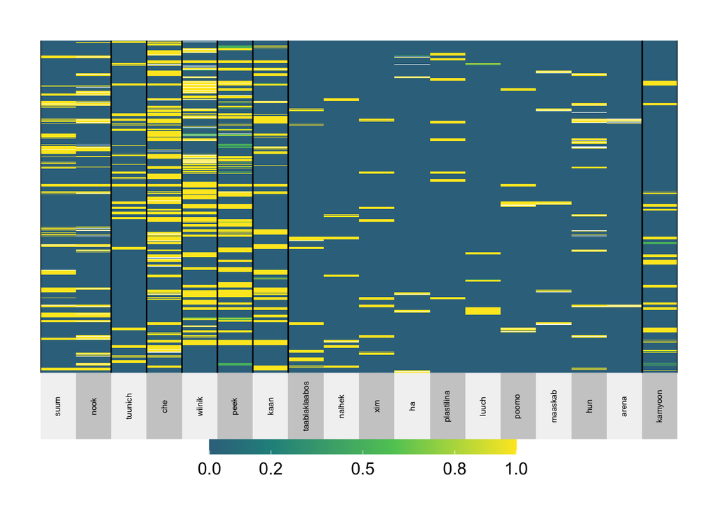

```r
# Heatmap to visualize figs/themes with many 0s
figs <- subset(dataset, select = -c(Root,Participant))
superheat(figs, heat.na.col = "white", n.clusters.cols = 8, clustering.method = 'hierarchical', bottom.label = "variable", bottom.label.text.size = 2, bottom.label.text.angle = 90)
```

For each root+figure/theme pair, the idea is to find the proportion of speakers that found that pair acceptable. In a previous analysis, I summed over each participant response for a given root+theme pair and divided that for the total number of participants. In this second analysis, I summed over each participant response for a given root+theme pair and divided that for the number of participants EXCLUDING NAs. Here’s an example:

| Root | Participant | ha |
| --- | --- | --- |
| ak | EMB | 1 |
| ak | FEE | 1 |
| ak | NMP | NA |
| ak | RMC | 1 |
| ak | SBM | 1 |
| ak | SME | 1 |

In the previous code, this gave 5/6 = 0.83 acceptability for the ak+ha pair. In the current code, this gives 5/5 = 1 acceptability for the ak+ha pair, so we’re omitting NAs. This analysis improved the variance accounted by the model by around 1.5%.

In cases where speakers identified a root applicable to part of the figure (e.g. part of the body), I assigned that 0.5 (same with cases where speakers expressed doubt)

| Root | Participant | kamyoon |
| --- | --- | --- |
| boch’ | EMB | 0.5 |
| boch’ | FEE | 0.5 |
| boch’ | NMP | 0 |
| boch’ | RMC | 0.5 |
| boch’ | SBM | 0 |
| boch’ | SME | 0.5 |

So 2/6 = 0.3 acceptability for the boch’+kamyoon pair.

# Multidimensional Scaling Analysis

Once the proportion of speakers that consider each pair of root+theme acceptable is calculated, we can create a distance matrix that will be the input of the MDS model, and fit the model. This is done below:

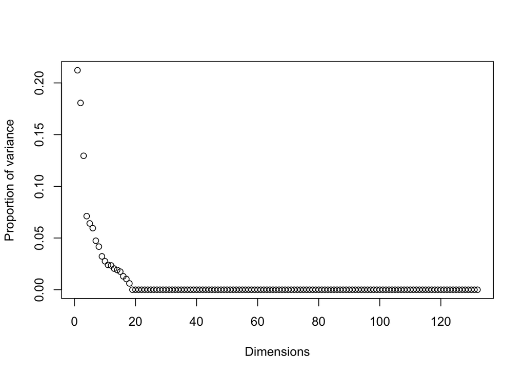

```r
# Calculate distance matrix using Euclidean distance
dm <- rdist(subset(df_prop, metric="euclidean"))

# Fit MDS
fit <- cmdscale(dm, eig=TRUE, x.ret=TRUE, k = 3)

# Calculate the percentage of variation that each MDS axis accounts for
var <- round(fit$eig/sum(fit$eig)*100, 1)

# Make a scree plot to show proportion of variance accounted for by each dimension
plot(fit$eig/sum(fit$eig), xlab="Dimensions", ylab="Proportion of variance")
```

```r
# Create data frame with solution
solution <- data.frame("Dimension.1"=fit$points[,1],
                       "Dimension.2"=fit$points[,2],
                       "Dimension.3"=fit$points[,3],
                       "Root" = rootnames)
```

Below is the same model but with the group of themes which showed to have the least number of 0s in the heatmap above (and thus were the themes most tested): suum, tuunich, nook, che, wiinik, peek, kaan, kamyoon. The new scree plot shows that the variance is distributed over a smaller number of dimensions, so I take this one to be a better model. In this analysis I extracted the first 7 dimensions. There are, at least, two approaches to choosing the number of dimensions for an MDS model. One is, by looking at the scree plot, to find the cutoff line where variation accounted for drops. This would be after dimension 3 in this case. The other approach is to consider all dimensions that account for more than 5% of the variation. This would be after dimension 7 in this case. In this analysis I took the second approach to explore more dimensions.

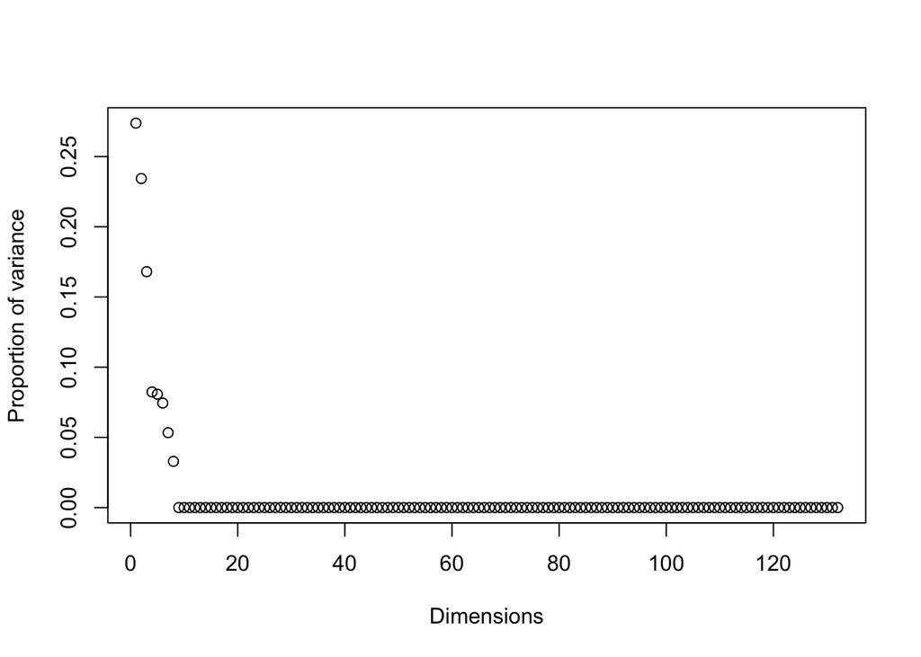

```r
# Select figs/themes with less 0s
ds <- subset(df_prop, select = c(suum,tuunich,nook,che,wiinik,peek,kaan,kamyoon))

# Calculate distance matrix using Euclidean distance
dm <- rdist(subset(ds, metric="euclidean"))

# Fit MDS
fit <- cmdscale(dm, eig=TRUE, x.ret=TRUE, k = 7)

# Calculate the percentage of variation that each MDS axis accounts for
var <- round(fit$eig/sum(fit$eig)*100, 1)

# Make a scree plot to show proportion of variance accounted for by each dimension
plot(fit$eig/sum(fit$eig), xlab="Dimensions", ylab="Proportion of variance")
```

```r
# Make a table to show proportion of variance accounted for by each dimension
var_table <- data.frame("Dimension"=c(1:7),"Variance"=var[1:7])
var_table
```

| Dimension | Variance |
| --- | --- |
| 1 | 27.4 |
| 2 | 23.4 |
| 3 | 16.8 |
| 4 | 8.2 |
| 5 | 8.1 |
| 6 | 7.4 |
| 7 | 5.3 |

```r
# Create data frame with solution
solution <- data.frame("Dimension.1"=fit$points[,1],
                       "Dimension.2"=fit$points[,2],
                       "Dimension.3"=fit$points[,3],
                       "Dimension.4"=fit$points[,4],
                       "Dimension.5"=fit$points[,5],
                       "Dimension.6"=fit$points[,6],
                       "Dimension.7"=fit$points[,7],
                       "Root" = rootnames)
```

Now we can plot the dimensions against each other to have a representation of the datapoints (dispositional roots) in two-dimensional space. Below are plots for each dimension against dimension 1 for convenience and to have a unified criteria for comparison. The distance between any two roots shows the degree to which they are simmilar, i.e., dispositional roots that are closed are more similar than roots that are further apart.

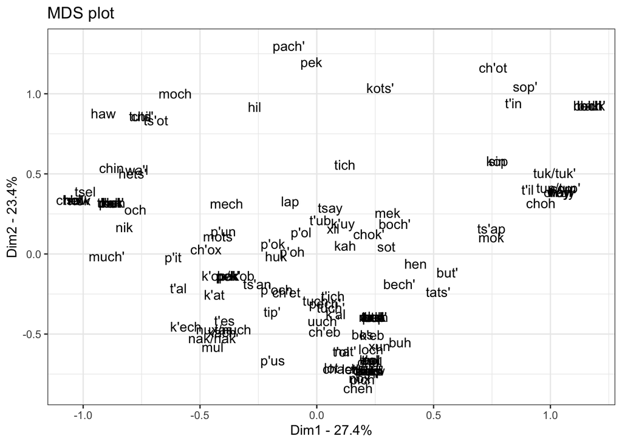

```r
# MDS plots

###############
# Dims 1 + 2
###############

ggplot(data=solution, aes(x=Dimension.1, y=Dimension.2, label=Root)) +
  geom_text() +
  #geom_text_repel() +
  theme_bw() +
  xlab(paste("Dim1 - ", var[1], "%", sep="")) +
  ylab(paste("Dim2 - ", var[2], "%", sep="")) +
  ggtitle("MDS plot")
```

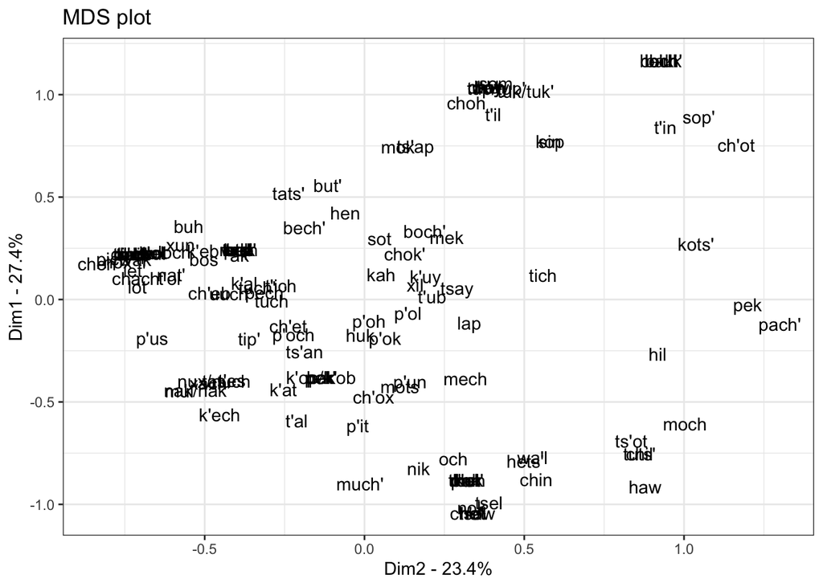

```r
###############
# Dims 2 + 1
###############

ggplot(data=solution, aes(x=Dimension.2, y=Dimension.1, label=Root)) +
  geom_text() +
  #geom_text_repel() +
  theme_bw() +
  xlab(paste("Dim2 - ", var[2], "%", sep="")) +
  ylab(paste("Dim1 - ", var[1], "%", sep="")) +
  ggtitle("MDS plot")
```

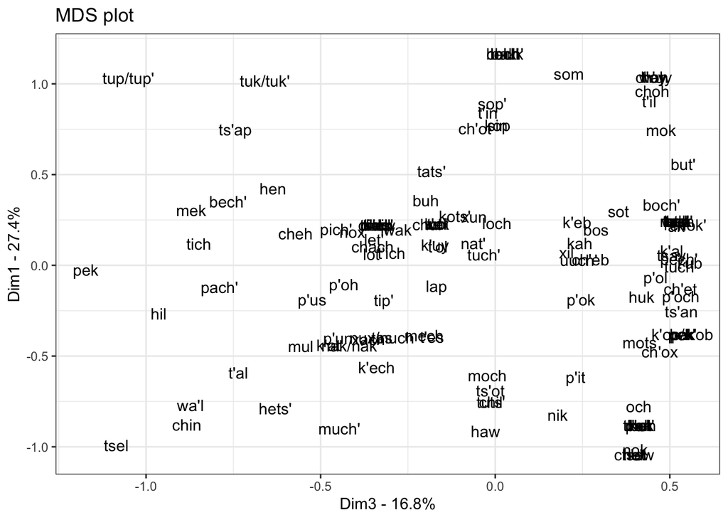

```r
###############
# Dims 3 + 1
###############

ggplot(data=solution, aes(x=Dimension.3, y=Dimension.1, label=Root)) +
  geom_text() +
  #geom_text_repel() +
  theme_bw() +
  xlab(paste("Dim3 - ", var[3], "%", sep="")) +
  ylab(paste("Dim1 - ", var[1], "%", sep="")) +
  ggtitle("MDS plot")
```

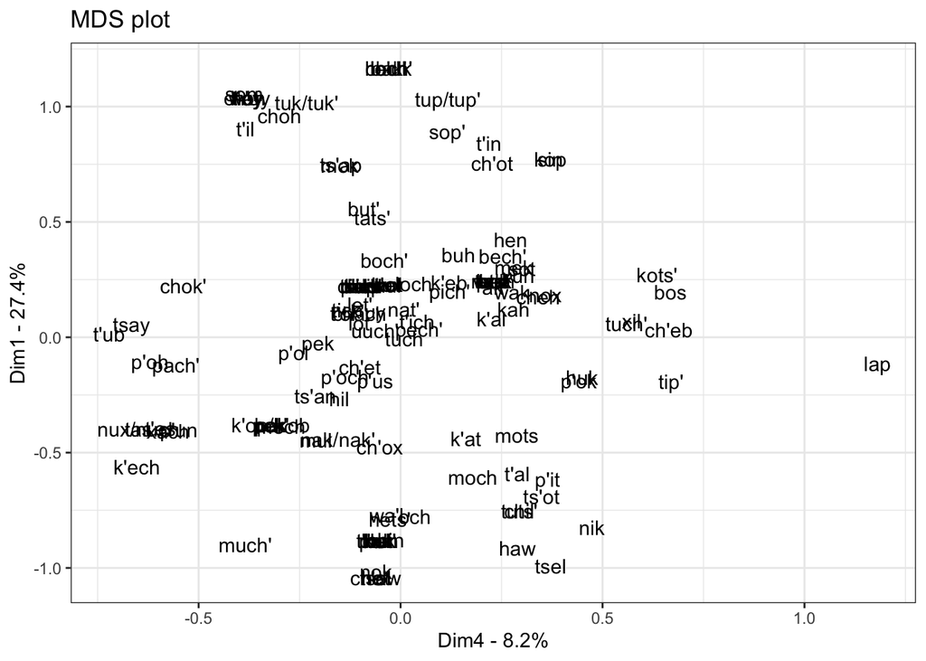

```r
###############
# Dims 4 + 1
###############

ggplot(data=solution, aes(x=Dimension.4, y=Dimension.1, label=Root)) +
  geom_text() +
  #geom_text_repel() +
  theme_bw() +
  xlab(paste("Dim4 - ", var[4], "%", sep="")) +
  ylab(paste("Dim1 - ", var[1], "%", sep="")) +
  ggtitle("MDS plot")
```

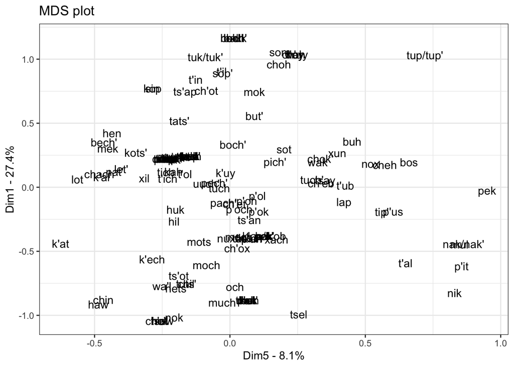

```r
###############
# Dims 5 + 1
###############

ggplot(data=solution, aes(x=Dimension.5, y=Dimension.1, label=Root)) +
  geom_text() +
  #geom_text_repel() +
  theme_bw() +
  xlab(paste("Dim5 - ", var[5], "%", sep="")) +
  ylab(paste("Dim1 - ", var[1], "%", sep="")) +
  ggtitle("MDS plot")
```

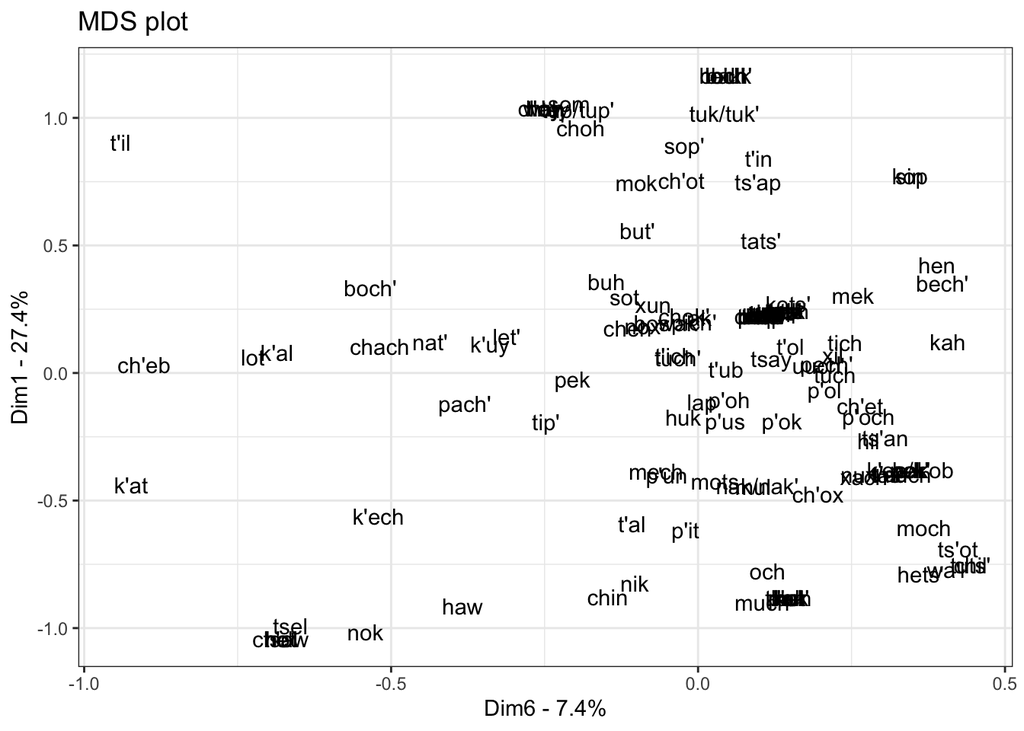

```r
###############
# Dims 6 + 1
###############

ggplot(data=solution, aes(x=Dimension.6, y=Dimension.1, label=Root)) +
  geom_text() +
  #geom_text_repel() +
  theme_bw() +
  xlab(paste("Dim6 - ", var[6], "%", sep="")) +
  ylab(paste("Dim1 - ", var[1], "%", sep="")) +
  ggtitle("MDS plot")
```

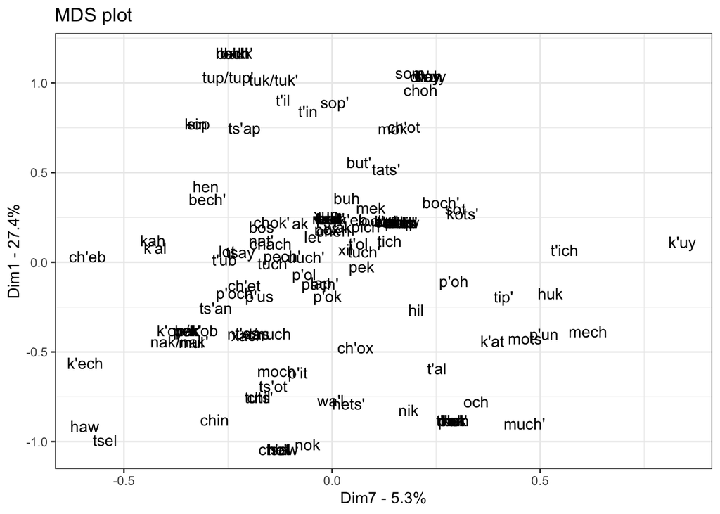

```r
###############
# Dims 7 + 1
###############

ggplot(data=solution, aes(x=Dimension.7, y=Dimension.1, label=Root)) +
  geom_text() +
  #geom_text_repel() +
  theme_bw() +
  xlab(paste("Dim7 - ", var[7], "%", sep="")) +
  ylab(paste("Dim1 - ", var[1], "%", sep="")) +
  ggtitle("MDS plot")
```

# Correlation with semantic categories

In this next section, I import the dataset created by Tim Tilbe for his QP and correlate the MDS dimensions with the semantic variables proposed in his dataset. Tilbe coded, for each proposed semantic dimension, 1 if a given dispositional root was hypothesized to be specified for this dimension, 0 if not, and 1?/0? if in doubt. For this analysis, I have replaced the doubful cases by NAs. Below is a summary of the dataset:

```r
#Import dataset with semantic dimensions
semdim <- read_csv("../QP_Data/Tilbe_dimensions.csv", col_types = cols(
  ROOT = col_factor(),
  Support = col_factor(),
  Leaning = col_factor(),
  Suspension = col_factor(),
  Blockage.of.motion = col_factor(),
  Orientation.in.vertical = col_factor(),
  Dispersion = col_factor(),
  Configuration.of.parts = col_factor(),
  Configuration.wrt.Ground= col_factor(),
  Containment = col_factor(),
  Length.of.vertical.dimension = col_factor(),
  Animate = col_factor(),
  Inanimate = col_factor(),
  Numerosity = col_factor(),
  Material.properties.specified = col_factor(),
  Potential.energy = col_factor(),
  Contact = col_factor()
  ))

# Change 0? and 1? into NAs
levels(semdim$Suspension)[levels(semdim$Suspension)=='1?'] <- NA
levels(semdim$Blockage.of.motion)[levels(semdim$Blockage.of.motion)=='0?'] <- NA
levels(semdim$Orientation.in.vertical)[levels(semdim$Orientation.in.vertical)=='1?'] <- NA
levels(semdim$Dispersion)[levels(semdim$Dispersion)=='1?'] <- NA
levels(semdim$Length.of.vertical.dimension)[levels(semdim$Length.of.vertical.dimension)=='1?'] <- NA
levels(semdim$Animate)[levels(semdim$Animate)=='1?'] <- NA
levels(semdim$Numerosity)[levels(semdim$Numerosity)=='1?'] <- NA
levels(semdim$Numerosity)[levels(semdim$Numerosity)=='0?'] <- NA
levels(semdim$Material.properties.specified)[levels(semdim$Material.properties.specified)=='1?'] <- NA
levels(semdim$Potential.energy)[levels(semdim$Potential.energy)=='1?'] <- NA
levels(semdim$Contact)[levels(semdim$Contact)=='1?'] <- NA
levels(semdim$Contact)[levels(semdim$Contact)=='0?'] <- NA

summary(semdim)
```

```
##       ROOT     Support   Leaning    Suspension Blockage.of.motion
##  ak     :  1   1   :56   0   :111   0   :111   1   : 11
##  bak'   :  1   0   :64   1   :  9   1   :  7   0   :108
##  bech'  :  1   NA's: 1   NA's:  1   NA's:  3   NA's:  2
##  boch'  :  1
##  bos    :  1
##  bot    :  1
##  (Other):115
##  Orientation.in.vertical Dispersion Configuration.of.parts
##  1   :25                 0   :95    0   :52
##  0   :94                 1   :24    1   :68
##  NA's: 2                 NA's: 2    NA's: 1
##
##
##
##
##  Configuration.wrt.Ground Containment Length.of.vertical.dimension Animate
##  1   :41                  1   : 12    1   :  8                     0   :37
##  0   :78                  0   :108    0   :107                     1   :83
##  NA's: 2                  NA's:  1    NA's:  6                     NA's: 1
##
##
##
##
##  Inanimate Numerosity Material.properties.specified Potential.energy Contact
##  1:101     0   :91    1   :33                       1   :29          0   :101
##  0: 20     1   :25    0   :86                       0   :85          1   : 14
##            NA's: 5    NA's: 2                       NA's: 7          NA's:  6
##
##
##
##
```

Because the dispositional roots in Tilbe’s dataset are not eactly the same in the one used in this analysis (Tilbe’s dataset has 121 roots and the one used in this analysis has 132), we have to make a subgroup of those roots that are used in both datasets to be able to correlate them. This is done below:

```r
# Keep only those rows that have roots in common (between semantic dimensions and mds dimensions dataframes)
semdimdf <- semdim[which(semdim$ROOT %in% rootnames),]
mdsdimdf <- solution[which(solution$Root %in% semdimdf$ROOT),]

# Merge both dataframes into one
both <- cbind(semdimdf,mdsdimdf)
```

Now we can test the correlation between MDS Dimensions and the semantic variables in Tilbe’s analysis. Below are boxplots for each dimension against each variable and the t-tests (following Baayen, 2008) that yielded a significant result:

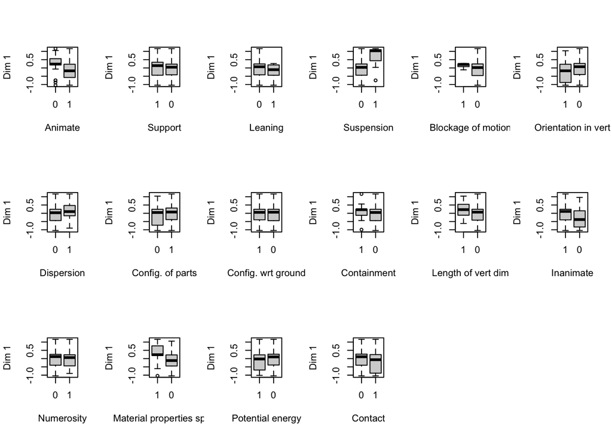

```
##
##  Welch Two Sample t-test
##
## data:  both$Dimension.1 by both$Animate
## t = 3.8746, df = 77.465, p-value = 0.000222
## alternative hypothesis: true difference in means is not equal to 0
## 95 percent confidence interval:
##  0.2018578 0.6286226
## sample estimates:
## mean in group 0 mean in group 1
##       0.2740653      -0.1411749
```

```
##
##  Welch Two Sample t-test
##
## data:  both$Dimension.1 by both$Suspension
## t = -2.5517, df = 6.4482, p-value = 0.04076
## alternative hypothesis: true difference in means is not equal to 0
## 95 percent confidence interval:
##  -1.3971090 -0.0409692
## sample estimates:
## mean in group 0 mean in group 1
##     -0.07109004      0.64794904
```

```
##
##  Welch Two Sample t-test
##
## data:  both$Dimension.1 by both$Material.properties.specified
## t = 3.8375, df = 58.434, p-value = 0.0003076
## alternative hypothesis: true difference in means is not equal to 0
## 95 percent confidence interval:
##  0.2094998 0.6662269
## sample estimates:
## mean in group 1 mean in group 0
##       0.3052742      -0.1325892
```

```
##
##  Welch Two Sample t-test
##
## data:  both$Dimension.1 by both$Blockage.of.motion
## t = 2.859, df = 81.938, p-value = 0.005389
## alternative hypothesis: true difference in means is not equal to 0
## 95 percent confidence interval:
##  0.06035011 0.33646693
## sample estimates:
## mean in group 1 mean in group 0
##      0.15501494     -0.04339358
```

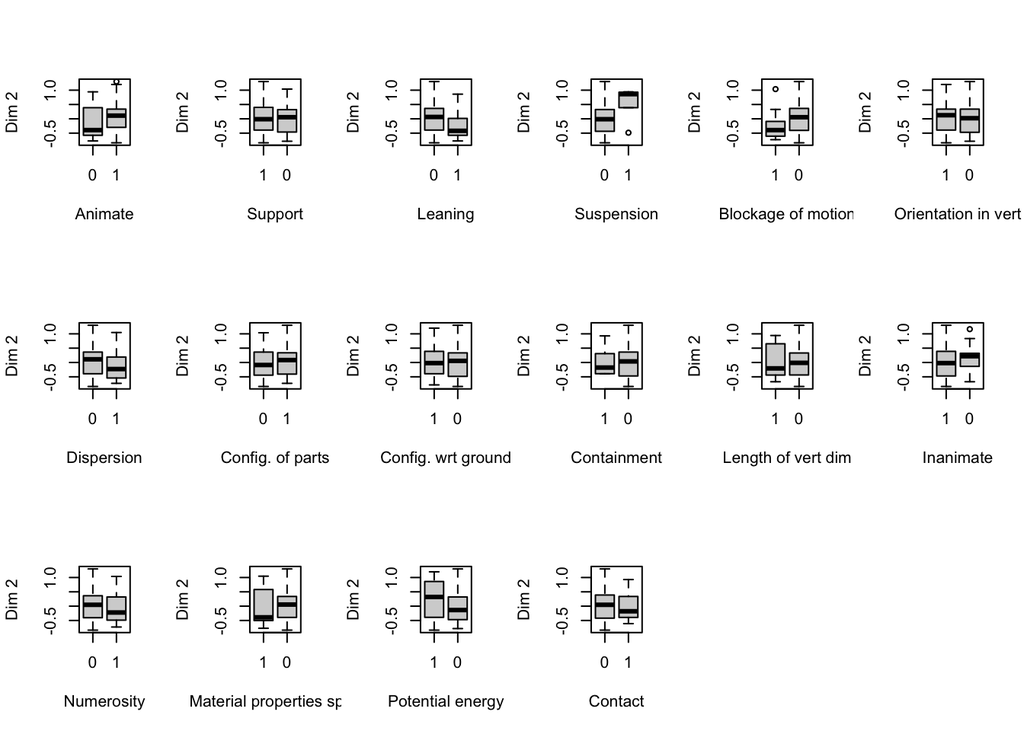

```
##
##  Welch Two Sample t-test
##
## data:  both$Dimension.2 by both$Suspension
## t = -2.8227, df = 6.76, p-value = 0.02663
## alternative hypothesis: true difference in means is not equal to 0
## 95 percent confidence interval:
##  -1.06538828 -0.09025622
## sample estimates:
## mean in group 0 mean in group 1
##     -0.01339885      0.56442341
```

```
##
##  Welch Two Sample t-test
##
## data:  both$Dimension.2 by both$Potential.energy
## t = 2.0656, df = 41.134, p-value = 0.0452
## alternative hypothesis: true difference in means is not equal to 0
## 95 percent confidence interval:
##  0.005896883 0.520640989
## sample estimates:
## mean in group 1 mean in group 0
##      0.20353125     -0.05973768
```

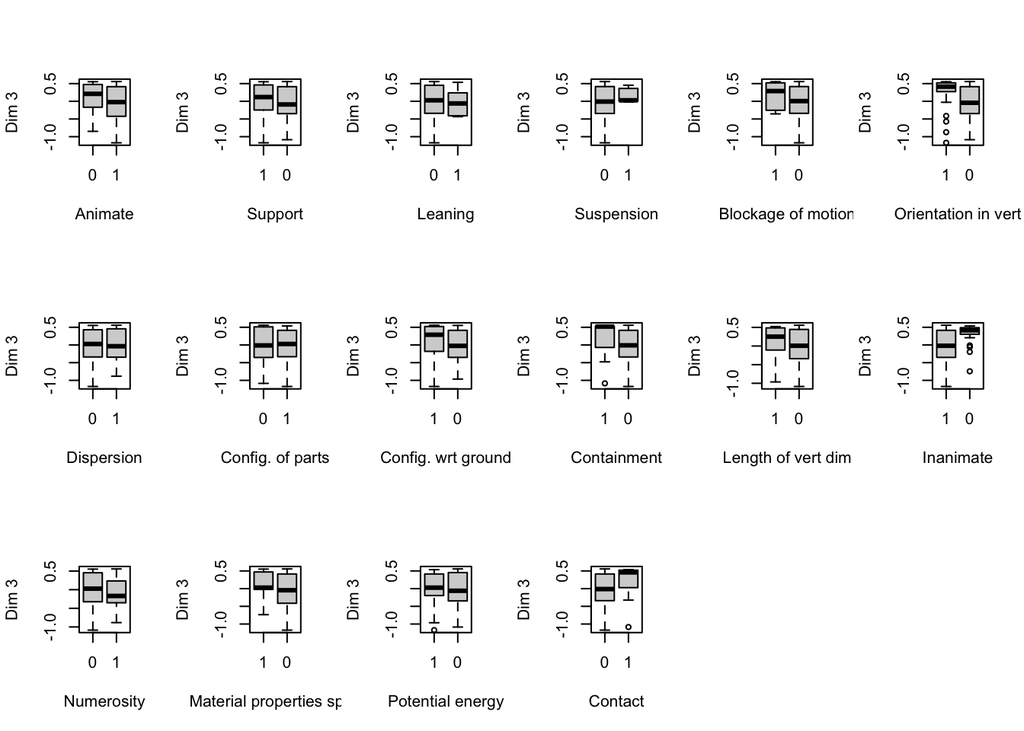

```
##
##  Welch Two Sample t-test
##
## data:  both$Dimension.3 by both$Animate
## t = 2.354, df = 89.383, p-value = 0.02076
## alternative hypothesis: true difference in means is not equal to 0
## 95 percent confidence interval:
##  0.02966799 0.35079025
## sample estimates:
## mean in group 0 mean in group 1
##       0.1381285      -0.0521006
```

```
##
##  Welch Two Sample t-test
##
## data:  both$Dimension.3 by both$Orientation.in.vertical
## t = 2.6596, df = 35.508, p-value = 0.01166
## alternative hypothesis: true difference in means is not equal to 0
## 95 percent confidence interval:
##  0.06659873 0.49522034
## sample estimates:
## mean in group 1 mean in group 0
##      0.22407996     -0.05682957
```

```
##
##  Welch Two Sample t-test
##
## data:  both$Dimension.3 by both$Inanimate
## t = -4.1536, df = 36.086, p-value = 0.0001915
## alternative hypothesis: true difference in means is not equal to 0
## 95 percent confidence interval:
##  -0.5286923 -0.1818025
## sample estimates:
## mean in group 1 mean in group 0
##     -0.05273788      0.30250952
```

```
##
##  Welch Two Sample t-test
##
## data:  both$Dimension.3 by both$Material.properties.specified
## t = 2.1147, df = 82.221, p-value = 0.03749
## alternative hypothesis: true difference in means is not equal to 0
## 95 percent confidence interval:
##  0.01004744 0.32877722
## sample estimates:
## mean in group 1 mean in group 0
##      0.12552027     -0.04389206
```

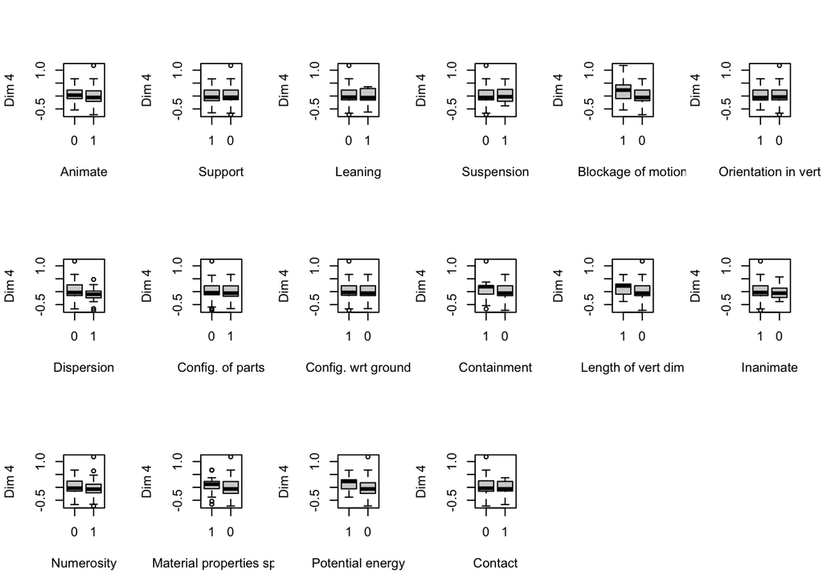

```
##
##  Welch Two Sample t-test
##
## data:  both$Dimension.4 by both$Dispersion
## t = 1.9682, df = 43.222, p-value = 0.05549
## alternative hypothesis: true difference in means is not equal to 0
## 95 percent confidence interval:
##  -0.003151728  0.260342734
## sample estimates:
## mean in group 0 mean in group 1
##       0.0181349      -0.1104606
```

```
##
##  Welch Two Sample t-test
##
## data:  both$Dimension.4 by both$Material.properties.specified
## t = 2.0782, df = 67.37, p-value = 0.04151
## alternative hypothesis: true difference in means is not equal to 0
## 95 percent confidence interval:
##  0.005133034 0.253925182
## sample estimates:
## mean in group 1 mean in group 0
##      0.08749458     -0.04203453
```

```
##
##  Welch Two Sample t-test
##
## data:  both$Dimension.4 by both$Potential.energy
## t = 2.7459, df = 61.138, p-value = 0.007914
## alternative hypothesis: true difference in means is not equal to 0
## 95 percent confidence interval:
##  0.04697036 0.29863431
## sample estimates:
## mean in group 1 mean in group 0
##      0.12708468     -0.04571765
```

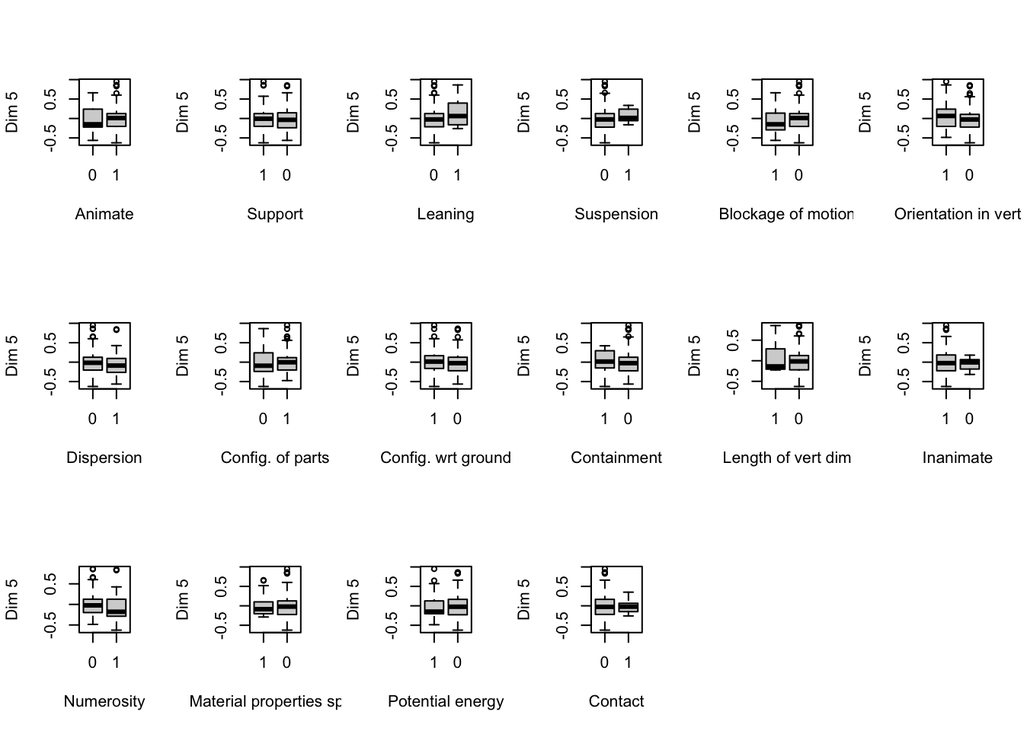

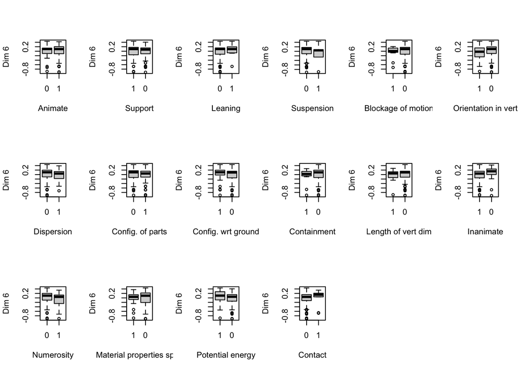

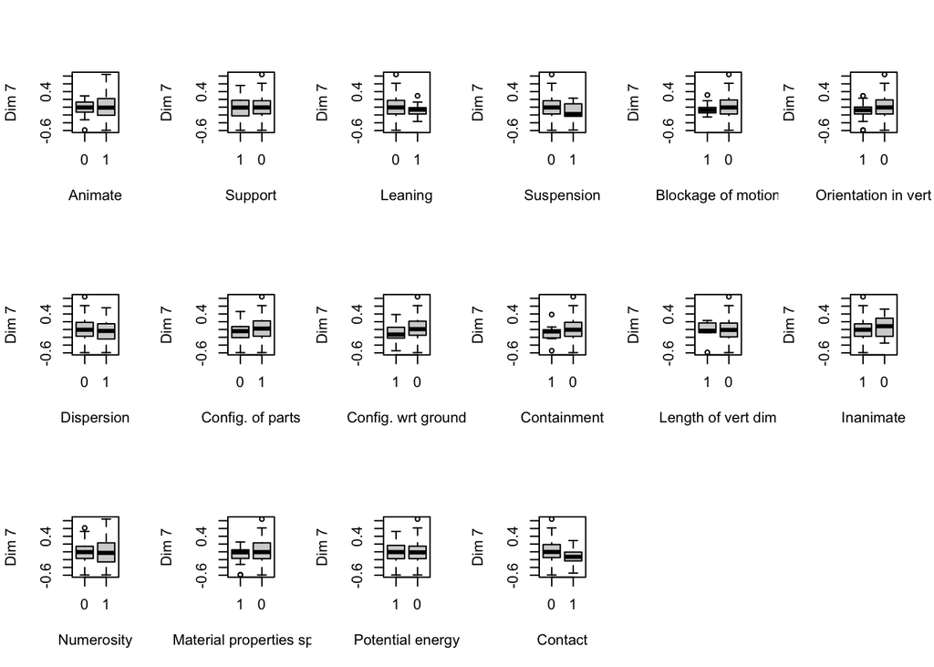

```
##
##  Welch Two Sample t-test
##
## data:  both$Dimension.7 by both$Orientation.in.vertical
## t = -2.0996, df = 41.712, p-value = 0.04185
## alternative hypothesis: true difference in means is not equal to 0
## 95 percent confidence interval:
##  -0.224601842 -0.004423577
## sample estimates:
## mean in group 1 mean in group 0
##     -0.09321076      0.02130195
```

```
##
##  Welch Two Sample t-test
##
## data:  both$Dimension.7 by both$Configuration.wrt.Ground
## t = -2.2135, df = 104.29, p-value = 0.02904
## alternative hypothesis: true difference in means is not equal to 0
## 95 percent confidence interval:
##  -0.19130823 -0.01050939
## sample estimates:
## mean in group 1 mean in group 0
##     -0.06831160      0.03259721
```

```
##
##  Welch Two Sample t-test
##
## data:  both$Dimension.7 by both$Contact
## t = 2.5118, df = 20.15, p-value = 0.02063
## alternative hypothesis: true difference in means is not equal to 0
## 95 percent confidence interval:
##  0.02529191 0.27237925
## sample estimates:
## mean in group 0 mean in group 1
##      0.02026108     -0.12857450
```

# Some preliminary conclusions

## Model comparison

The table below shows a comparison of the variance accounted for by the first three dimensions of the different MDS models tested. W/NA vs No NA makes reference to the way the proportion of speakers that found a pair of root+theme acceptable was calculated (recall the example above, where 1,1,NA,1,1,1 would give 0.83 for W/NA and 1 for No NA). All themes vs Selected themes makes reference to the number of theme/figures that were included in the analysis. For the selected themes models, the themes used where the most tested ones, as shown in the heatmap above. The table shows that the current analysis (a model with No NA, Selected themes), is the one that accounts for more variance in the data.

| Dimension | W/NA, All themes | W/NA, Selected themes | No NA, All themes | No NA, Selected themes |
| --- | --- | --- | --- | --- |
| 1 | 21.5% | 27.9% | 21.2% | 27.4% |
| 2 | 17% | 21.6% | 18.1% | 23.4% |
| 3 | 12.2% | 16.6% | 13% | 16.8% |
| TOTAL | 50.7% | 66.1% | 52.3% | 67.6% |

## MDS dimensions and semantic categories

The table below shows, for the current analysis, the MDS dimensions together with the variance accounted for by each of them, and the semantic variables they were found to correlate with, together with the p-values yielded by the two-sample t-tests.

[output not shown]

List of semantic variables that were found NOT to be significant to this analysis: Support, Leaning, Containment, Length of vertical dimension, Numerosity.